# R-For-DS

Aristide NIYONGABO - 20252MBI042

2026-10-31

# R for Data Science

## Important definitions in data science

- Statistics
- Modelling
- Computation
- Calculus

## Today’s class: what we will study

- Installation of R
- Installation of RStudio
- Calculator in R
- Data importation in R
- Data description using numerical measures and graphs
- Data structures: vectors, factors, lists, data frames, matrices, and arrays

## Data structures in R

### Vector: the foundational R data structure

#### Numeric

Example 1:

```r
x <- c(0.5, 0.6)
age <- c(20, 35, 32, 29)
summary(age)
```

```
##    Min. 1st Qu.  Median    Mean 3rd Qu.    Max.
##   20.00   26.75   30.50   29.00   32.75   35.00
```

Example 2:

```r
age <- c(35, 24, 18, 24)
mean(age)
```

```
## [1] 25.25
```

#### Logical

```r
x <- c(TRUE, FALSE)
x <- c(T, F)
```

#### Character

```r
x <- c("a", "b", "c")
class <- c("M", "F", "F", "M")
```

#### Integer

```r
x <- 9:29
```

#### Complex

```r
x <- c(1 + 0i, 2 + 4i)
```

### Matrix and matrix operations

```r
(x <- matrix(1:6, nrow = 2, ncol = 3))
```

```
##      [,1] [,2] [,3]
## [1,]    1    3    5
## [2,]    2    4    6
```

```r
x
```

```
##      [,1] [,2] [,3]
## [1,]    1    3    5
## [2,]    2    4    6
```

```r
(y <- matrix(1:6, nrow = 3, ncol = 2))
```

```
##      [,1] [,2]
## [1,]    1    4
## [2,]    2    5
## [3,]    3    6
```

```r
x %*% y
```

```
##      [,1] [,2]
## [1,]   22   49
## [2,]   28   64
```

### List

```r
(x <- list(1, "a", TRUE, 1 + 4i))
```

```
## [[1]]
## [1] 1
##
## [[2]]
## [1] "a"
##
## [[3]]
## [1] TRUE
##
## [[4]]
## [1] 1+4i
```

```r
x
```

```
## [[1]]
## [1] 1
##
## [[2]]
## [1] "a"
##
## [[3]]
## [1] TRUE
##
## [[4]]
## [1] 1+4i
```

### Factor

```r
x <- factor(c("yes", "yes", "no", "yes", "no"))
```

### Missing values

Create a vector with NAs:

```r
x <- c(1, 2, NA, 10, 3)
```

Return a logical vector indicating which elements are NA:

```r
is.na(x)
```

```
## [1] FALSE FALSE  TRUE FALSE FALSE
```

```r
x <- c(1, 2, 4, "NA", 5)
bad <- is.na(x)
print(bad)
```

```
## [1] FALSE FALSE FALSE FALSE FALSE
```

```r
x[!bad]
```

```
## [1] "1"  "2"  "4"  "NA" "5"
```

What if there are multiple R objects and you want to take the subset with no missing values in any of those objects?

```r
x <- c(1, 2, NA, 4, NA, 5)
y <- c("a", "b", NA, "d", NA, "f")
good <- complete.cases(x, y)
good
```

```
## [1]  TRUE  TRUE FALSE  TRUE FALSE  TRUE
```

## Coercion

If a character is present in a vector, R converts everything in the vector to character strings.

If a vector contains only logical values and numbers, R converts the logical values to numbers; every `TRUE` becomes `1`, and every `FALSE` becomes `0`.

```r
sum(c(TRUE, TRUE, FALSE, FALSE, FALSE))
```

```
## [1] 2
```

## Create data

Data frames are more general than matrices because a data frame can contain different data types (numeric, character, etc.), similar to what you can see in SPSS or SAS.

### Let’s create a data frame

```r
studentID <- c(1, 2, 3, 4, 5)
math_score <- c(12, 17, 10, 9, NA)
gender <- c("M", "F", "M", "M", "F")
it_score <- c(13, 18, 11, 10, 19)
scoredata <- data.frame(studentID, gender, math_score, it_score)
scoredata
```

```
##   studentID gender math_score it_score
## 1         1      M         12       13
## 2         2      F         17       18
## 3         3      M         10       11
## 4         4      M          9       10
## 5         5      F         NA       19
```

### Create data from keyboard

Steps:

1. Create a data frame (or matrix) with variable names.
2. Invoke the text editor on the created object.

```r
data_class2 <- data.frame(height = numeric(0), weight = numeric(0), bmi = numeric(0))
# data_class2 <- edit(data_class2)
```

## Data importation

R can import data from different sources, such as:

- Text files (ASCII, XML, web scraping)
- Spreadsheets
- Statistical packages (SAS, SPSS, Stata)
- Database management systems (SQL, MySQL, Oracle, Access)

### Homework: import data from a statistical package and from a database management system

```r
data_class <- read.table("datasets/class_data.txt", header = TRUE)
variable.names(data_class)
```

```
## [1] "HEIGHT" "WEIGHT"
```

```r
head(data_class)
```

```
##   HEIGHT WEIGHT
## 1    161     50
## 2    155     49
## 3    158     42
## 4    170     65
## 5    160     60
## 6    156     52
```

```r
tail(data_class)
```

```
##    HEIGHT WEIGHT
## 38    164     47
## 39    163     52
## 40    168     55
## 41    157     48
## 42    164     58
## 43    154     55
```

```r
data_class[10:20, ]
```

```
##    HEIGHT WEIGHT
## 10    167     51
## 11    160     60
## 12    155     42
## 13    154     53
## 14    155     48
## 15    157     48
## 16    157     48
## 17    160     53
## 18    158     52
## 19    160     51
## 20    160     53
```

```r
summary(data_class$WEIGHT)
```

```
##    Min. 1st Qu.  Median    Mean 3rd Qu.    Max.
##   42.00   48.00   52.00   52.47   56.00   65.00
```

```r
length(data_class$WEIGHT)
```

```
## [1] 43
```

```r
data_class[, -1]
```

```
##  [1] 50 49 42 65 60 52 58 46 45 51 60 42 53 48 48 48 53 52 51 53 44 56 63 52 57
## [26] 49 52 54 46 50 61 55 45 63 60 56 52 47 52 55 48 58 55
```

```r
data_class$WEIGHT
```

```
##  [1] 50 49 42 65 60 52 58 46 45 51 60 42 53 48 48 48 53 52 51 53 44 56 63 52 57
## [26] 49 52 54 46 50 61 55 45 63 60 56 52 47 52 55 48 58 55
```

### Using built-in datasets in R

```r
data() # list of datasets currently available
data("airquality")
variable.names(airquality)
```

```
## [1] "Ozone"   "Solar.R" "Wind"    "Temp"    "Month"   "Day"
```

```r
str(airquality)
```

```
## 'data.frame':    153 obs. of  6 variables:
##  $ Ozone  : int  41 36 12 18 NA 28 23 19 8 NA ...
##  $ Solar.R: int  190 118 149 313 NA NA 299 99 19 194 ...
##  $ Wind   : num  7.4 8 12.6 11.5 14.3 14.9 8.6 13.8 20.1 8.6 ...
##  $ Temp   : int  67 72 74 62 56 66 65 59 61 69 ...
##  $ Month  : int  5 5 5 5 5 5 5 5 5 5 ...
##  $ Day    : int  1 2 3 4 5 6 7 8 9 10 ...
```

## Exploratory data analysis

Examine numerical variables using common summaries:

```r
data_class
```

```
##    HEIGHT WEIGHT
## 1     161     50
## 2     155     49
## 3     158     42
## 4     170     65
## 5     160     60
## 6     156     52
## 7     162     58
## 8     158     46
## 9     158     45
## 10    167     51
## 11    160     60
## 12    155     42
## 13    154     53
## 14    155     48
```

[output cut: 29 more lines]

```r
summary(data_class)
```

```
##      HEIGHT          WEIGHT
##  Min.   :150.0   Min.   :42.00
##  1st Qu.:156.0   1st Qu.:48.00
##  Median :159.0   Median :52.00
##  Mean   :159.3   Mean   :52.47
##  3rd Qu.:162.0   3rd Qu.:56.00
##  Max.   :170.0   Max.   :65.00
```

```r
str(data_class)
```

```
## 'data.frame':    43 obs. of  2 variables:
##  $ HEIGHT: int  161 155 158 170 160 156 162 158 158 167 ...
##  $ WEIGHT: int  50 49 42 65 60 52 58 46 45 51 ...
```

### Summary statistics

```r
summary(data_class)
```

```
##      HEIGHT          WEIGHT
##  Min.   :150.0   Min.   :42.00
##  1st Qu.:156.0   1st Qu.:48.00
##  Median :159.0   Median :52.00
##  Mean   :159.3   Mean   :52.47
##  3rd Qu.:162.0   3rd Qu.:56.00
##  Max.   :170.0   Max.   :65.00
```

```r
apply(data_class, 1, mean)
```

```
##  [1] 105.5 102.0 100.0 117.5 110.0 104.0 110.0 102.0 101.5 109.0 110.0  98.5
## [13] 103.5 101.5 102.5 102.5 106.5 105.0 105.5 106.5  98.0 105.0 106.5 106.5
## [25] 109.5 106.5 106.5 104.5 102.5 106.5 110.0 107.5 101.5 114.0 108.0 109.5
## [37] 103.5 105.5 107.5 111.5 102.5 111.0 104.5
```

```r
apply(data_class, 2, sd)
```

```
##   HEIGHT   WEIGHT
## 4.304444 5.750150
```

```r
c(mean(data_class$HEIGHT), sd(data_class$HEIGHT))
```

```
## [1] 159.255814   4.304444
```

```r
c(mean(data_class$WEIGHT), sd(data_class$WEIGHT))
```

```
## [1] 52.46512  5.75015
```

```r
c(Mean = mean(data_class$HEIGHT), SD = sd(data_class$HEIGHT))
```

```
##       Mean         SD
## 159.255814   4.304444
```

```r
c(Mean = mean(data_class$WEIGHT), SD = sd(data_class$WEIGHT))
```

```
##     Mean       SD
## 52.46512  5.75015
```

## Variation and covariation using both numerical and graphical methods

### Relationship between a categorical and a continuous variable

```r
data("iris")
head(iris)
```

```
##   Sepal.Length Sepal.Width Petal.Length Petal.Width Species
## 1          5.1         3.5          1.4         0.2  setosa
## 2          4.9         3.0          1.4         0.2  setosa
## 3          4.7         3.2          1.3         0.2  setosa
## 4          4.6         3.1          1.5         0.2  setosa
## 5          5.0         3.6          1.4         0.2  setosa
## 6          5.4         3.9          1.7         0.4  setosa
```

```r
mean(iris$Petal.Length)
```

```
## [1] 3.758
```

```r
mean(iris$Petal.Length[iris$Species == "setosa"])
```

```
## [1] 1.462
```

```r
mean(iris$Petal.Length[iris$Species == "versicolor"])
```

```
## [1] 4.26
```

```r
mean(iris$Petal.Length[iris$Species == "virginica"])
```

```
## [1] 5.552
```

```r
by(iris$Petal.Length, iris$Species, mean)
```

```
## iris$Species: setosa
## [1] 1.462
## ------------------------------------------------------------
## iris$Species: versicolor
## [1] 4.26
## ------------------------------------------------------------
## iris$Species: virginica
## [1] 5.552
```

```r
by(iris$Petal.Length, iris$Species, sd)
```

```
## iris$Species: setosa
## [1] 0.173664
## ------------------------------------------------------------
## iris$Species: versicolor
## [1] 0.469911
## ------------------------------------------------------------
## iris$Species: virginica
## [1] 0.5518947
```

```r
by(iris$Petal.Length, iris$Species, summary)
```

```
## iris$Species: setosa
##    Min. 1st Qu.  Median    Mean 3rd Qu.    Max.
##   1.000   1.400   1.500   1.462   1.575   1.900
## ------------------------------------------------------------
## iris$Species: versicolor
##    Min. 1st Qu.  Median    Mean 3rd Qu.    Max.
##    3.00    4.00    4.35    4.26    4.60    5.10
## ------------------------------------------------------------
## iris$Species: virginica
##    Min. 1st Qu.  Median    Mean 3rd Qu.    Max.
##   4.500   5.100   5.550   5.552   5.875   6.900
```

Visualize differences in continuous variables between categories using a box-and-whisker plot:

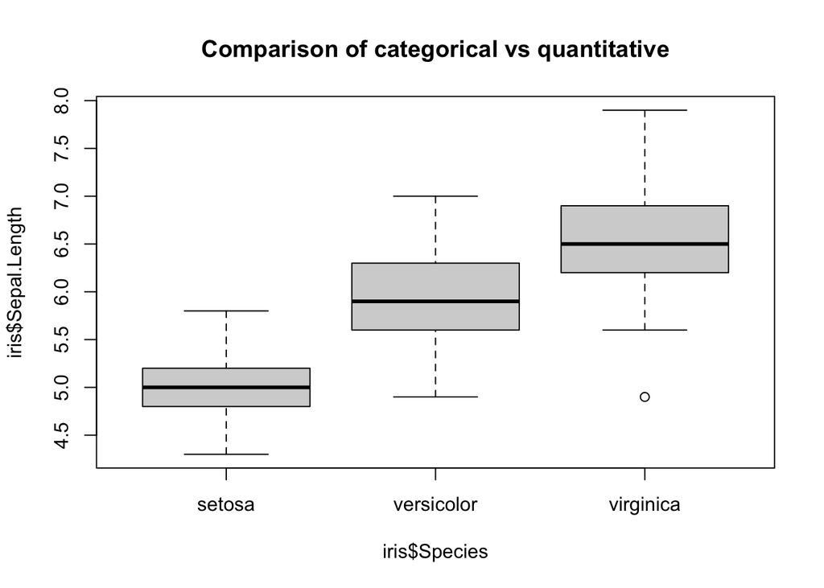

```r
boxplot(iris$Sepal.Length ~ iris$Species,
    data = iris,
    main = "Comparison of categorical vs quantitative"
)
```

### Relationship between two categorical variables

```r
ucba <- data.frame(UCBAdmissions)
head(ucba)
```

```
##      Admit Gender Dept Freq
## 1 Admitted   Male    A  512
## 2 Rejected   Male    A  313
## 3 Admitted Female    A   89
## 4 Rejected Female    A   19
## 5 Admitted   Male    B  353
## 6 Rejected   Male    B  207
```

```r
cross <- xtabs(Freq ~ Gender + Admit, data = ucba)
(cross <- xtabs(Freq ~ Gender + Admit, data = ucba))
```

```
##         Admit
## Gender   Admitted Rejected
##   Male       1198     1493
##   Female      557     1278
```

```r
prop.table(cross, 1)
```

```
##         Admit
## Gender    Admitted  Rejected
##   Male   0.4451877 0.5548123
##   Female 0.3035422 0.6964578
```

## Simpson’s paradox

This is a phenomenon where a trend that appears in combined groups disappears or reverses when the data are broken down into groups.

```r
cross2 <- xtabs(Freq ~ Gender + Admit, data = ucba[ucba$Dept == "F", ])
prop.table(cross2, 1)
```

```
##         Admit
## Gender     Admitted   Rejected
##   Male   0.05898123 0.94101877
##   Female 0.07038123 0.92961877
```

## Graphical summaries

### Bar chart

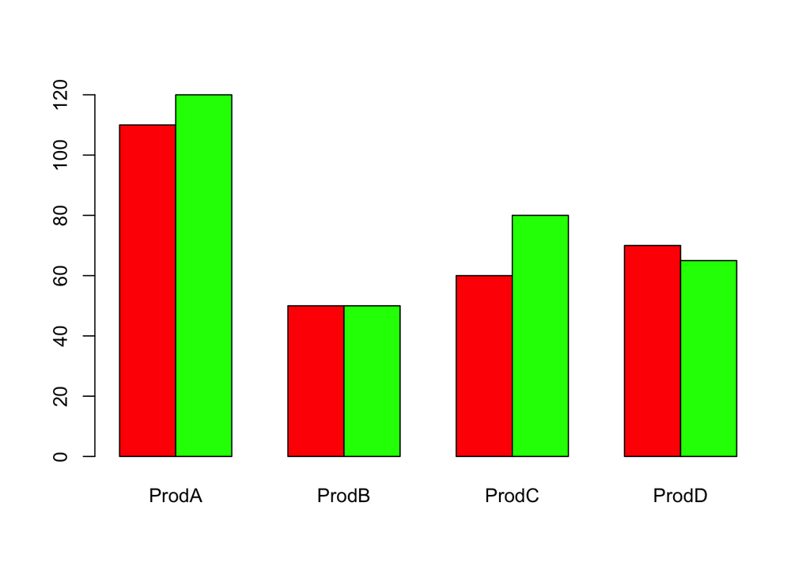

```r
dat <- read.table(text = "ProdA ProdB ProdC ProdD
1 110 50 60 70
2 120 50 80 65", header = TRUE)

barplot(as.matrix(dat), beside = TRUE, col = c("Red", "green"))
```

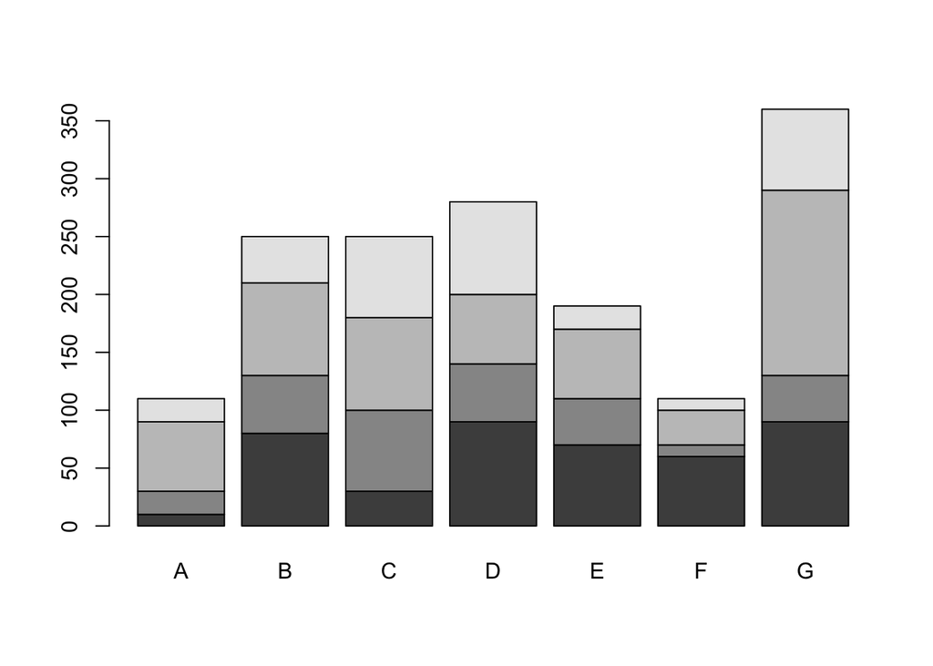

```r
dat <- read.table(text = "A   B   C   D   E   F    G
1 10 80 30 90 70 60  90
2 20 50 70 50 40 10  40
3 60 80 80 60 60 30 160
4 20 40 70 80 20 10  70", header = TRUE)

barplot(as.matrix(dat))
```

### Scatter plot

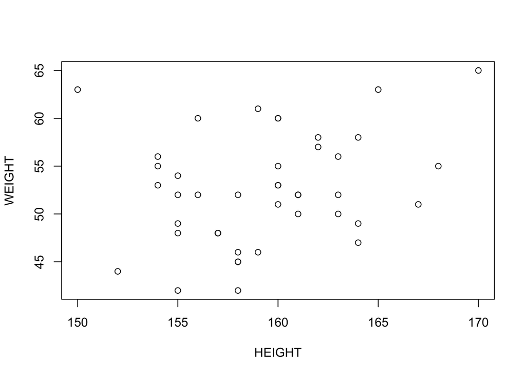

```r
plot(WEIGHT ~ HEIGHT, data = data_class)
```

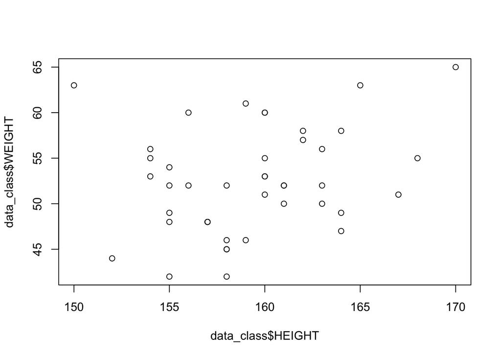

```r
plot(data_class$HEIGHT, data_class$WEIGHT)
```

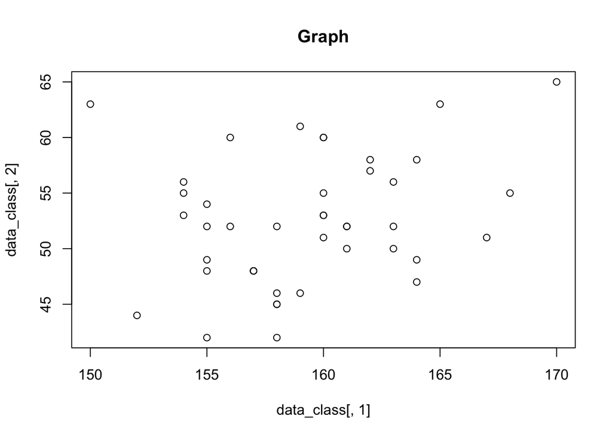

```r
plot(data_class[, 1], data_class[, 2], main = "Graph")
```

```r
cor(data_class$HEIGHT, data_class$WEIGHT)
```

```
## [1] 0.2663495
```

## Linear models

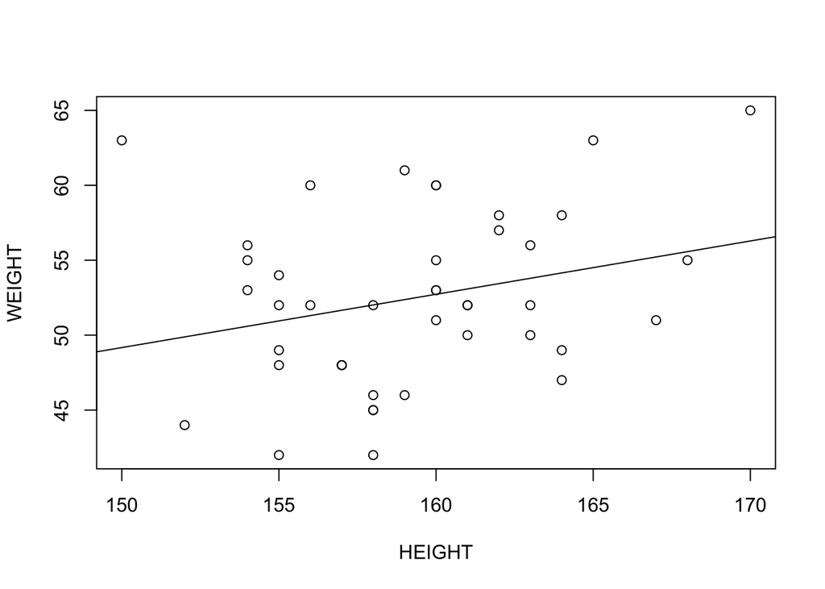

```r
plot(WEIGHT ~ HEIGHT, data = data_class)
abline(lm(WEIGHT ~ HEIGHT, data = data_class)$coefficient)
```

```r
data_lm <- lm(HEIGHT ~ WEIGHT, data = data_class)
summary(data_lm)
```

```
##
## Call:
## lm(formula = HEIGHT ~ WEIGHT, data = data_class)
##
## Residuals:
##      Min       1Q   Median       3Q      Max
## -11.3563  -2.6662   0.2326   2.0378   8.2449
##
## Coefficients:
##             Estimate Std. Error t value Pr(>|t|)
## (Intercept) 148.7951     5.9466  25.022   <2e-16 ***
## WEIGHT        0.1994     0.1127   1.769   0.0843 .
## ---
## Signif. codes:  0 '***' 0.001 '**' 0.01 '*' 0.05 '.' 0.1 ' ' 1
##
## Residual standard error: 4.199 on 41 degrees of freedom
## Multiple R-squared:  0.07094,    Adjusted R-squared:  0.04828
## F-statistic: 3.131 on 1 and 41 DF,  p-value: 0.08427
```

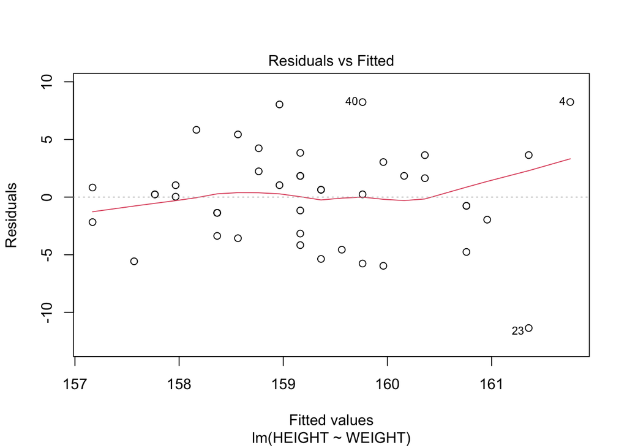

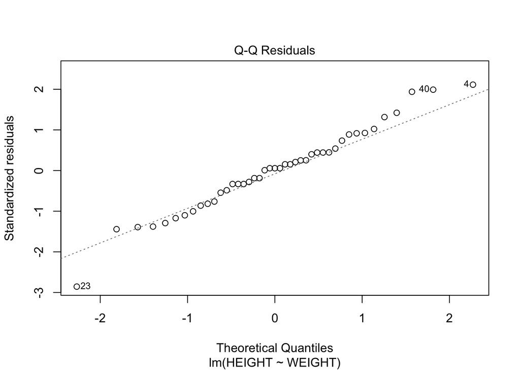

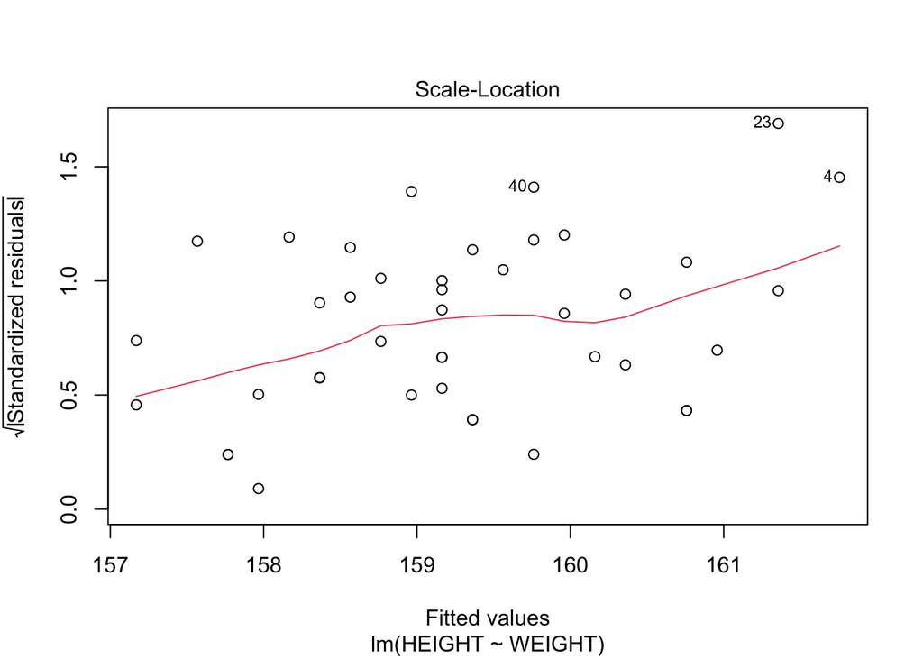

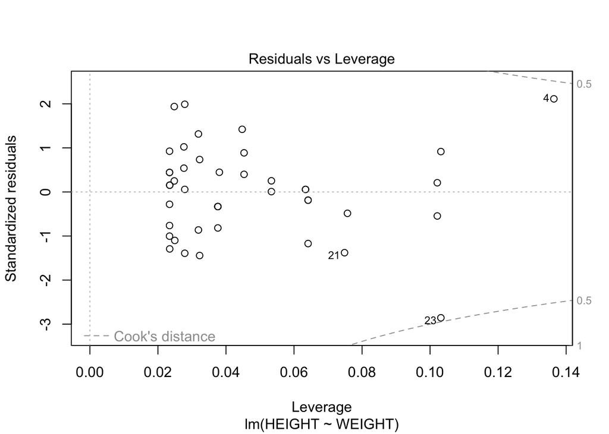

```r
plot(data_lm)
```

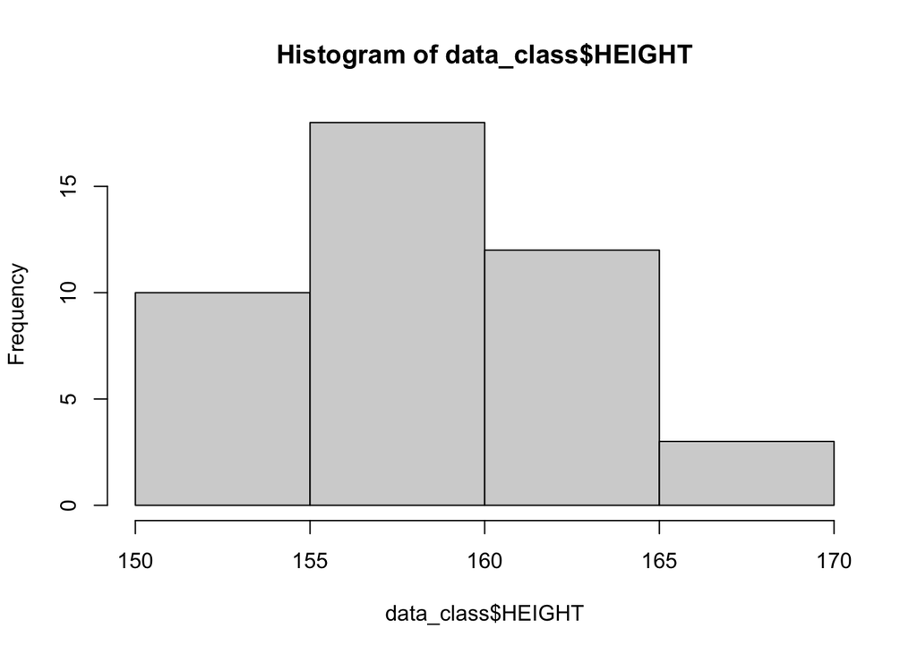

```r
hist(data_class$HEIGHT)
```

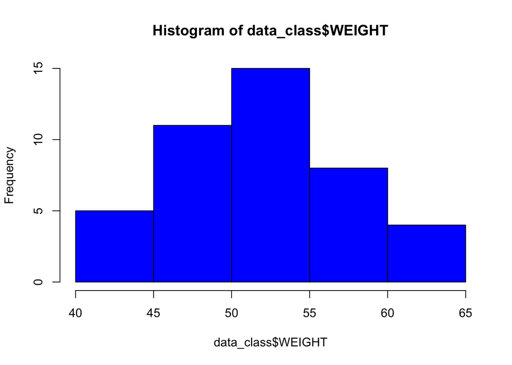

```r
hist(data_class$WEIGHT, col = "blue")
```

A linear model with a smooth line:

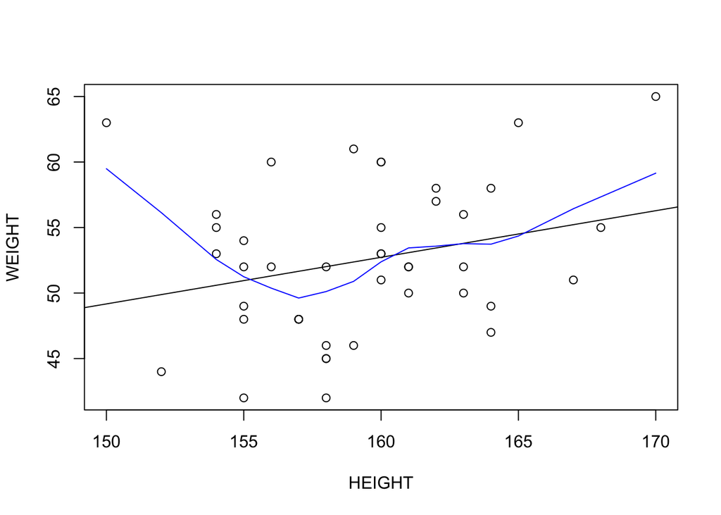

```r
plot(WEIGHT ~ HEIGHT, data = data_class)
abline(lm(WEIGHT ~ HEIGHT, data = data_class)$coefficient)
lines(lowess(data_class$HEIGHT, data_class$WEIGHT), col = "blue")
```

```r
cor(data_class$HEIGHT, data_class$WEIGHT)
```

```
## [1] 0.2663495
```

```r
lm(WEIGHT ~ HEIGHT, data = data_class)
```

```
##
## Call:
## lm(formula = WEIGHT ~ HEIGHT, data = data_class)
##
## Coefficients:
## (Intercept)       HEIGHT
##     -4.1992       0.3558
```

## Data management

Create another variable:

```r
attach(data_class)
(BMI <- WEIGHT / (HEIGHT / 100)^2)
```

```
##  [1] 19.28938 20.39542 16.82423 22.49135 23.43750 21.36752 22.10029 18.42653
##  [9] 18.02596 18.28678 23.43750 17.48179 22.34778 19.97919 19.47341 19.47341
## [17] 20.70312 20.83000 19.92187 20.70312 19.04432 23.61275 28.00000 20.06095
## [25] 21.71925 18.21832 20.06095 22.47659 18.19548 18.81892 24.12879 21.48437
## [33] 18.02596 23.14050 24.65483 21.07720 21.64412 17.47472 19.57168 19.48696
## [41] 19.47341 21.56454 23.19109
```

```r
(BMI <- round(WEIGHT / (HEIGHT / 100)^2, digit = 2))
```

```
##  [1] 19.29 20.40 16.82 22.49 23.44 21.37 22.10 18.43 18.03 18.29 23.44 17.48
## [13] 22.35 19.98 19.47 19.47 20.70 20.83 19.92 20.70 19.04 23.61 28.00 20.06
## [25] 21.72 18.22 20.06 22.48 18.20 18.82 24.13 21.48 18.03 23.14 24.65 21.08
## [37] 21.64 17.47 19.57 19.49 19.47 21.56 23.19
```

```r
head(cbind(data_class, BMI), n = 5)
```

```
##   HEIGHT WEIGHT   BMI
## 1    161     50 19.29
## 2    155     49 20.40
## 3    158     42 16.82
## 4    170     65 22.49
## 5    160     60 23.44
```

```r
new_data_class <- cbind(data_class, BMI)
tail(cbind(data_class, BMI), n = 10)
```

```
##    HEIGHT WEIGHT   BMI
## 34    165     63 23.14
## 35    156     60 24.65
## 36    163     56 21.08
## 37    155     52 21.64
## 38    164     47 17.47
## 39    163     52 19.57
## 40    168     55 19.49
## 41    157     48 19.47
## 42    164     58 21.56
## 43    154     55 23.19
```

```r
summary(BMI)
```

```
##    Min. 1st Qu.  Median    Mean 3rd Qu.    Max.
##   16.82   19.16   20.40   20.70   22.23   28.00
```

```r
stem(BMI, scale = 2)
```

```
##
##   The decimal point is at the |
##
##   16 | 8
##   17 | 55
##   18 | 0022348
##   19 | 03555569
##   20 | 0114778
##   21 | 145667
##   22 | 1455
##   23 | 12446
##   24 | 17
##   25 |
##   26 |
##   27 |
##   28 | 0
```

## Dates

```r
today <- Sys.Date()
format(today, format = "%B %d %Y")
```

```
## [1] "October 31 2026"
```

```r
format(today, format = "%A")
```

```
## [1] "Saturday"
```

```r
today <- Sys.Date()
dob <- as.Date("1982-02-10")
# today <- as.Date("2024-08-25")
difftime(today, dob, units = "days")
```

```
## Time difference of 16334 days
```

```r
startdate <- as.Date("2004-02-13")
enddate <- as.Date("2011-01-22")
days <- enddate - startdate
days
```

```
## Time difference of 2535 days
```

## Subsetting

Use `$`, `[ ]`, or `[[ ]]` to subset data. For example:

```r
manager <- c(1, 2, 3, 4, 5)
country <- c("US", "US", "UK", "UK", "UK")
gender <- c("M", "F", "F", "M", "F")
age <- c(32, 45, 25, 39, 99)
q1 <- c(5, 3, 3, 3, 2)
q2 <- c(4, 5, 5, 3, 2)
q3 <- c(5, 2, 5, 4, 1)
q4 <- c(5, 5, 5, NA, 2)
q5 <- c(5, 5, 2, NA, 1)
leadership <- data.frame(manager, country, gender, age, q1, q2, q3, q4, q5,
    stringsAsFactors = TRUE
)
leadership <- data.frame(manager, country, gender, age, q1, q2, q3, q4, q5)
str(leadership)
```

```
## 'data.frame':    5 obs. of  9 variables:
##  $ manager: num  1 2 3 4 5
##  $ country: chr  "US" "US" "UK" "UK" ...
##  $ gender : chr  "M" "F" "F" "M" ...
##  $ age    : num  32 45 25 39 99
##  $ q1     : num  5 3 3 3 2
##  $ q2     : num  4 5 5 3 2
##  $ q3     : num  5 2 5 4 1
##  $ q4     : num  5 5 5 NA 2
##  $ q5     : num  5 5 2 NA 1
```

```r
names(leadership)
```

```
## [1] "manager" "country" "gender"  "age"     "q1"      "q2"      "q3"
## [8] "q4"      "q5"
```

What you can do:

- combine the scores of the five questions
- handle missing values
- create a dataset of the variables you want
- create age groups
- note that `99` indicates a missing value

### Missing value handling

```r
leadership$age[leadership$age == 99] <- NA
leadership
```

```
##   manager country gender age q1 q2 q3 q4 q5
## 1       1      US      M  32  5  4  5  5  5
## 2       2      US      F  45  3  5  2  5  5
## 3       3      UK      F  25  3  5  5  5  2
## 4       4      UK      M  39  3  3  4 NA NA
## 5       5      UK      F  NA  2  2  1  2  1
```

```r
leadership$agecat[leadership$age > 75] <- "Elder"
leadership$agecat[leadership$age >= 35 & leadership$age <= 75] <- "Middle Aged"
leadership$agecat[leadership$age < 35] <- "Young"
```

Listwise deletion is one of several methods of handling incomplete datasets. You may also replace missing values by the mean of the remaining data.

```r
is.na(leadership[, 5:9])
```

```
##         q1    q2    q3    q4    q5
## [1,] FALSE FALSE FALSE FALSE FALSE
## [2,] FALSE FALSE FALSE FALSE FALSE
## [3,] FALSE FALSE FALSE FALSE FALSE
## [4,] FALSE FALSE FALSE  TRUE  TRUE
## [5,] FALSE FALSE FALSE FALSE FALSE
```

```r
newdata <- na.omit(leadership)
newdata
```

```
##   manager country gender age q1 q2 q3 q4 q5      agecat
## 1       1      US      M  32  5  4  5  5  5       Young
## 2       2      US      F  45  3  5  2  5  5 Middle Aged
## 3       3      UK      F  25  3  5  5  5  2       Young
```

### Sorting data

```r
order(leadership$age)
```

```
## [1] 3 1 4 2 5
```

```r
newdata2 <- leadership[order(leadership$age), ]
```

### Merging data sets

To merge two data frames horizontally, use `merge()`. In most cases, two data frames are joined by one or more common key variables.

To join two datasets vertically, use `rbind()`; note that the two data sets must have the same variables.

### Selecting variables and observations

```r
newdata3 <- leadership[, c(5:9)]
myvars <- c("q1", "q2", "q3", "q4", "q5")
(newdata3 <- leadership[myvars])
```

```
##   q1 q2 q3 q4 q5
## 1  5  4  5  5  5
## 2  3  5  2  5  5
## 3  3  5  5  5  2
## 4  3  3  4 NA NA
## 5  2  2  1  2  1
```

```r
newdata4 <- leadership[, c(-1, -2)]
(newdata4 <- leadership[, -(1:5)])
```

```
##   q2 q3 q4 q5      agecat
## 1  4  5  5  5       Young
## 2  5  2  5  5 Middle Aged
## 3  5  5  5  2       Young
## 4  3  4 NA NA Middle Aged
## 5  2  1  2  1        <NA>
```

```r
newdata5 <- leadership[, c(-1, -7)]
leadership[[4]]
```

```
## [1] 32 45 25 39 NA
```

```r
leadership$age
```

```
## [1] 32 45 25 39 NA
```

```r
newdata6 <- leadership[c(-1, -3), ]
newdata6 <- leadership[c(2, 4, 5), ]
newdata7 <- subset(leadership, age >= 35 | age < 24, select = c(q1, q2, q3, q4, q5))
```

```r
attach(leadership)
(newdata7 <- leadership[gender == "M" & age > 30, ])
```

```
##   manager country gender age q1 q2 q3 q4 q5      agecat
## 1       1      US      M  32  5  4  5  5  5       Young
## 4       4      UK      M  39  3  3  4 NA NA Middle Aged
```

```r
detach(leadership)
```

This concludes the first class on R for data science.